# Multi-Omic Biomarker Discovery with stablr

## Overview

**Why multi-omic?** Single-omic analyses can miss biomarkers that are individually weak but collectively informative. By combining immune-cell profiling (CyTOF) with protein abundance (Proteomics), we can ask whether each layer contributes independent signal and how to integrate them optimally.

We cover:

1. Loading the bundled example data with `load_ool_data()`.
2. Running per-omic STABL — a useful baseline before integration.
3. Running the integrated multi-omic workflow with **early fusion** and **late fusion**.
4. Comparing selected features across strategies.
5. Exporting results.

## Learning objectives

By the end of this vignette you will be able to:

1. Understand the data structure returned by `load_ool_data()`.
2. Run STABL independently on each omic and interpret the outputs.
3. Explain the difference between early fusion and late fusion.
4. Run `stabl_multiomic_train_validate()` and navigate its result list.
5. Compare which features appear across integration strategies.
6. Export results for downstream use.

```r
library(stablr)
```

## 1. Load the data

`load_ool_data()` reads the pre-bundled OOL subset directly from the package. No file paths are needed. It returns a named list with two elements:

- **`$x_list`**: a named list of feature matrices, one per omic layer. Each matrix has samples in rows and features in columns, with matching row names.
- **`$y`**: a named numeric vector of outcomes (DOS in days), aligned to the rows of every matrix in `$x_list`.

```r
ool_train <- load_ool_data(split = "train")
ool_valid <- load_ool_data(split = "valid")

# Training set dimensions
lapply(ool_train$x_list, dim)
```

```
#> $cytof
#> [1] 150 100
#>
#> $proteomics
#> [1] 150 100
```

```r
length(ool_train$y)
```

```
#> [1] 150
```

```r
# Validation set dimensions
lapply(ool_valid$x_list, dim)
```

```
#> $cytof
#> [1]  21 100
#>
#> $proteomics
#> [1]  21 100
```

```r
# Outcome distribution (DOS = days before onset of labor)
summary(ool_train$y)
```

```
#>    Min. 1st Qu.  Median    Mean 3rd Qu.    Max.
#> -113.00  -70.75  -35.50  -43.39  -15.00    0.00
```

## 2. Per-omic STABL

Before running the integrated pipeline, it is instructive to see which features STABL selects in each omic independently. This per-omic step serves two purposes:

1. **Sanity check** — does each omic contain any signal at all? If STABL selects zero features from an omic, that layer may not contribute useful information to the integrated analysis.
2. **Baseline** — the per-omic biomarker lists can be compared to the integrated results to see which features survive the joint analysis.

We use `n_bootstraps = 150` throughout this vignette. Increase to 500-1000 for publication-quality results.

**Reading the printed summary:** after printing each fit, look at (1) the number of features selected and (2) the FDP estimate. A small number of selected features with a low FDP (< 0.05) is the ideal outcome.

```r
lambda_cytof <- auto_lambda_grid(
  ool_train$x_list$cytof, ool_train$y,
  family = "gaussian", n_lambda = 20
)
```

```r
fit_cytof <- stabl_fit(
  x               = ool_train$x_list$cytof,
  y               = ool_train$y,
  lambda_grid     = lambda_cytof,
  family          = "gaussian",
  n_bootstraps    = 150L,
  artificial_type = "random_permutation",
  random_state    = 42L
)
fit_cytof
```

```
#> <stabl_fit>
#>   Features in:      100
#>   Features selected: 0
#>   Min FDP+:         1
#>   FDP+ threshold:   1
#>   Artificial:       random_permutation
```

```r
lambda_prot <- auto_lambda_grid(
  ool_train$x_list$proteomics, ool_train$y,
  family = "gaussian", n_lambda = 20
)

fit_prot <- stabl_fit(
  x               = ool_train$x_list$proteomics,
  y               = ool_train$y,
  lambda_grid     = lambda_prot,
  family          = "gaussian",
  n_bootstraps    = 150L,
  artificial_type = "random_permutation",
  random_state    = 42L
)
fit_prot
```

```
#> <stabl_fit>
#>   Features in:      100
#>   Features selected: 2
#>   Min FDP+:         0.5
#>   FDP+ threshold:   0.92
#>   Artificial:       random_permutation
```

```r
cat("CyTOF selected features:
")
```

```
#> CyTOF selected features:
```

```r
print(get_support(fit_cytof))
```

```
#>     Granulocytes_CREB_unstim    Granulocytes_STAT5_unstim
#>                        FALSE                        FALSE
#>      Granulocytes_p38_unstim    Granulocytes_STAT1_unstim
#>                        FALSE                        FALSE
#>    Granulocytes_STAT3_unstim       Granulocytes_S6_unstim
#>                        FALSE                        FALSE
#>      Granulocytes_IkB_unstim Granulocytes_MAPKAPK2_unstim
#>                        FALSE                        FALSE
#>     Granulocytes_NFkB_unstim      Granulocytes_ERK_unstim
#>                        FALSE                        FALSE
#>    Granulocytes_STAT6_unstim           Bcells_CREB_unstim
#>                        FALSE                        FALSE
#>          Bcells_STAT5_unstim            Bcells_p38_unstim
#>                        FALSE                        FALSE
#>          Bcells_STAT1_unstim          Bcells_STAT3_unstim
#>                        FALSE                        FALSE
#>             Bcells_S6_unstim            Bcells_IkB_unstim
#>                        FALSE                        FALSE
#>       Bcells_MAPKAPK2_unstim           Bcells_NFkB_unstim
#>                        FALSE                        FALSE
#>            Bcells_ERK_unstim          Bcells_STAT6_unstim
#>                        FALSE                        FALSE
#>             cMCs_CREB_unstim            cMCs_STAT5_unstim
#>                        FALSE                        FALSE
#>              cMCs_p38_unstim            cMCs_STAT1_unstim
#>                        FALSE                        FALSE
#>            cMCs_STAT3_unstim               cMCs_S6_unstim
#>                        FALSE                        FALSE
#>              cMCs_IkB_unstim         cMCs_MAPKAPK2_unstim
#>                        FALSE                        FALSE
#>             cMCs_NFkB_unstim              cMCs_ERK_unstim
#>                        FALSE                        FALSE
#>            cMCs_STAT6_unstim      CCR2poscMCs_CREB_unstim
#>                        FALSE                        FALSE
#>     CCR2poscMCs_STAT5_unstim       CCR2poscMCs_p38_unstim
#>                        FALSE                        FALSE
#>     CCR2poscMCs_STAT1_unstim     CCR2poscMCs_STAT3_unstim
#>                        FALSE                        FALSE
#>        CCR2poscMCs_S6_unstim       CCR2poscMCs_IkB_unstim
#>                        FALSE                        FALSE
```

[output cut: 45 more lines]

```
#>                        FALSE                        FALSE
#>              pDCs_ERK_unstim            pDCs_STAT6_unstim
#>                        FALSE                        FALSE
#>           intMCs_CREB_unstim          intMCs_STAT5_unstim
#>                        FALSE                        FALSE
#>            intMCs_p38_unstim          intMCs_STAT1_unstim
#>                        FALSE                        FALSE
#>          intMCs_STAT3_unstim             intMCs_S6_unstim
#>                        FALSE                        FALSE
#>            intMCs_IkB_unstim       intMCs_MAPKAPK2_unstim
#>                        FALSE                        FALSE
#>           intMCs_NFkB_unstim            intMCs_ERK_unstim
#>                        FALSE                        FALSE
#>          intMCs_STAT6_unstim    CCR2posintMCs_CREB_unstim
#>                        FALSE                        FALSE
```

```r
cat("
Proteomics selected features:
")
```

```
#>
#> Proteomics selected features:
```

```r
print(get_support(fit_prot))
```

```
#>                       CHIP                      CEBPB
#>                      FALSE                      FALSE
#>                        NSE                      PIAS4
#>                      FALSE                      FALSE
#>                   IL.10.Ra                      STAT3
#>                      FALSE                      FALSE
#>                       IRF1                      c.Jun
#>                      FALSE                      FALSE
#>                      Mcl.1                       OAS1
#>                      FALSE                      FALSE
#>                      c.Myc                      SMAD3
#>                      FALSE                      FALSE
#>                      SMAD2                      IL.23
#>                      FALSE                      FALSE
#>                     PDGFRA                      IL.12
#>                      FALSE                      FALSE
#>                      STAT1                      STAT6
#>                      FALSE                      FALSE
#>                      LRRK2                Osteocalcin
#>                      FALSE                      FALSE
#>                       IL.5                       GPDA
#>                      FALSE                      FALSE
#>                        IgA                       LPPL
#>                      FALSE                      FALSE
#>                      HEMK2                       PDXK
#>                       TRUE                      FALSE
#>                       TLR4                       REG4
#>                      FALSE                      FALSE
#>                     HSP.27                     YKL.40
#>                      FALSE                      FALSE
#>              Alpha.enolase                     Apo.L1
#>                      FALSE                      FALSE
#>                       CD38                       CD59
#>                      FALSE                      FALSE
#>                      FABPL                     GDF.11
#>                      FALSE                      FALSE
#>                        BTC                     HIF.1a
#>                      FALSE                      FALSE
#>                     S100A6                     SECTM1
#>                      FALSE                      FALSE
```

[output cut: 45 more lines]

```
#>                      FALSE                      FALSE
#>                      C1QR1                       NRG4
#>                      FALSE                      FALSE
#>                      H2B2E                       H2A3
#>                       TRUE                      FALSE
#>                        H31                      IFN.g
#>                      FALSE                      FALSE
#>                     IL.1F8                     IL.1F6
#>                      FALSE                      FALSE
#>                       UCRP                  Ephrin.A3
#>                      FALSE                      FALSE
#> X14.3.3.protein.beta.alpha                   X14.3.3E
#>                      FALSE                      FALSE
#>                  Annexin.V                  Myostatin
#>                      FALSE                      FALSE
```

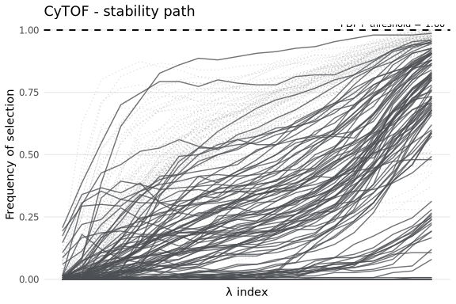

```r
plot_stabl_path(fit_cytof,     title = "CyTOF - stability path")
```

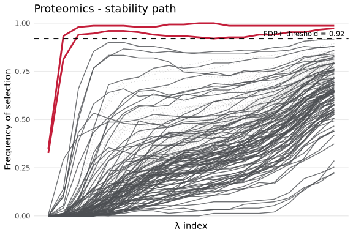

```r
plot_stabl_path(fit_prot,      title = "Proteomics - stability path")
```

## 3. Integrated multi-omic workflow

`stabl_multiomic_train_validate()` orchestrates the full pipeline in a single call. It accepts training and validation splits and evaluates two complementary integration strategies:

| Strategy | How it works | Best when |
| --- | --- | --- |
| **Early fusion** | Concatenates all omic matrices into one wide matrix, then runs a *single* STABL fit across all features jointly. | Omics are measured on the same samples; you want a unified biomarker list. |
| **Late fusion** | Fits one STABL + downstream model per omic separately, then learns the optimal weighted combination of predictions on the validation set. | You want to know each omic’s independent predictive contribution. |

Key arguments:

| Argument | Purpose |
| --- | --- |
| `x_train_list` / `x_valid_list` | Named lists of feature matrices; names must match between train and valid. |
| `lambda_grid` | Named list of lambda grids, one per omic (names must match `x_train_list`). |
| `early_fusion` / `late_fusion` | Toggle each strategy on or off independently. |
| `n_iter_lf` | Number of optimisation iterations for the late-fusion weight search. |

```r
# Build per-omic lambda grids
lambda_list <- list(
  cytof      = auto_lambda_grid(ool_train$x_list$cytof,
                                ool_train$y, family = "gaussian", n_lambda = 20),
  proteomics = auto_lambda_grid(ool_train$x_list$proteomics,
                                ool_train$y, family = "gaussian", n_lambda = 20)
)
```

```r
multi_fit <- stabl_multiomic_train_validate(
  x_train_list    = ool_train$x_list,
  y_train         = ool_train$y,
  lambda_grid     = lambda_list,
  x_valid_list    = ool_valid$x_list,
  y_valid         = ool_valid$y,
  family          = "gaussian",
  n_bootstraps    = 150L,
  artificial_type = "random_permutation",
  early_fusion    = TRUE,
  late_fusion     = TRUE,
  n_iter_lf       = 1000L,
  random_state    = 42L
)

multi_fit
```

```
#> <stabl_multiomic_fit>
#>   Omics:           2 (cytof, proteomics)
#>   Per-omic selected features:
#>     cytof: 0
#>     proteomics: 2
#>   Validation data:  yes
#>   Early fusion:     yes (7 features selected)
#>   Late fusion:      yes (score = 0.3607)
```

## 4. Exploring results

`multi_fit` is a list with the following elements:

- **`$fits`**: named list of `stabl_fit` objects, one per omic. These are the per-omic STABL results produced *within* the joint pipeline.
- **`$early_fusion`**: result of the early-fusion step (if `early_fusion = TRUE`), containing `$fit` (a `stabl_fit` on the concatenated matrix).
- **`$late_fusion`**: result of the late-fusion step (if `late_fusion = TRUE`), containing `$valid_predictions` (validation predictions) and `$weights` (per-omic importance weights).

```r
# Per-omic selected features from the joint pipeline
cat("CyTOF (from multi-omic pipeline):
")
```

```
#> CyTOF (from multi-omic pipeline):
```

```r
print(get_support(multi_fit$fits$cytof))
```

```
#>     Granulocytes_CREB_unstim    Granulocytes_STAT5_unstim
#>                        FALSE                        FALSE
#>      Granulocytes_p38_unstim    Granulocytes_STAT1_unstim
#>                        FALSE                        FALSE
#>    Granulocytes_STAT3_unstim       Granulocytes_S6_unstim
#>                        FALSE                        FALSE
#>      Granulocytes_IkB_unstim Granulocytes_MAPKAPK2_unstim
#>                        FALSE                        FALSE
#>     Granulocytes_NFkB_unstim      Granulocytes_ERK_unstim
#>                        FALSE                        FALSE
#>    Granulocytes_STAT6_unstim           Bcells_CREB_unstim
#>                        FALSE                        FALSE
#>          Bcells_STAT5_unstim            Bcells_p38_unstim
#>                        FALSE                        FALSE
#>          Bcells_STAT1_unstim          Bcells_STAT3_unstim
#>                        FALSE                        FALSE
#>             Bcells_S6_unstim            Bcells_IkB_unstim
#>                        FALSE                        FALSE
#>       Bcells_MAPKAPK2_unstim           Bcells_NFkB_unstim
#>                        FALSE                        FALSE
#>            Bcells_ERK_unstim          Bcells_STAT6_unstim
#>                        FALSE                        FALSE
#>             cMCs_CREB_unstim            cMCs_STAT5_unstim
#>                        FALSE                        FALSE
#>              cMCs_p38_unstim            cMCs_STAT1_unstim
#>                        FALSE                        FALSE
#>            cMCs_STAT3_unstim               cMCs_S6_unstim
#>                        FALSE                        FALSE
#>              cMCs_IkB_unstim         cMCs_MAPKAPK2_unstim
#>                        FALSE                        FALSE
#>             cMCs_NFkB_unstim              cMCs_ERK_unstim
#>                        FALSE                        FALSE
#>            cMCs_STAT6_unstim      CCR2poscMCs_CREB_unstim
#>                        FALSE                        FALSE
#>     CCR2poscMCs_STAT5_unstim       CCR2poscMCs_p38_unstim
#>                        FALSE                        FALSE
#>     CCR2poscMCs_STAT1_unstim     CCR2poscMCs_STAT3_unstim
#>                        FALSE                        FALSE
#>        CCR2poscMCs_S6_unstim       CCR2poscMCs_IkB_unstim
#>                        FALSE                        FALSE
```

[output cut: 45 more lines]

```
#>                        FALSE                        FALSE
#>              pDCs_ERK_unstim            pDCs_STAT6_unstim
#>                        FALSE                        FALSE
#>           intMCs_CREB_unstim          intMCs_STAT5_unstim
#>                        FALSE                        FALSE
#>            intMCs_p38_unstim          intMCs_STAT1_unstim
#>                        FALSE                        FALSE
#>          intMCs_STAT3_unstim             intMCs_S6_unstim
#>                        FALSE                        FALSE
#>            intMCs_IkB_unstim       intMCs_MAPKAPK2_unstim
#>                        FALSE                        FALSE
#>           intMCs_NFkB_unstim            intMCs_ERK_unstim
#>                        FALSE                        FALSE
#>          intMCs_STAT6_unstim    CCR2posintMCs_CREB_unstim
#>                        FALSE                        FALSE
```

```r
cat("
Proteomics (from multi-omic pipeline):
")
```

```
#>
#> Proteomics (from multi-omic pipeline):
```

```r
print(get_support(multi_fit$fits$proteomics))
```

```
#>                       CHIP                      CEBPB
#>                      FALSE                      FALSE
#>                        NSE                      PIAS4
#>                      FALSE                      FALSE
#>                   IL.10.Ra                      STAT3
#>                      FALSE                      FALSE
#>                       IRF1                      c.Jun
#>                      FALSE                      FALSE
#>                      Mcl.1                       OAS1
#>                      FALSE                      FALSE
#>                      c.Myc                      SMAD3
#>                      FALSE                      FALSE
#>                      SMAD2                      IL.23
#>                      FALSE                      FALSE
#>                     PDGFRA                      IL.12
#>                      FALSE                      FALSE
#>                      STAT1                      STAT6
#>                      FALSE                      FALSE
#>                      LRRK2                Osteocalcin
#>                      FALSE                      FALSE
#>                       IL.5                       GPDA
#>                      FALSE                      FALSE
#>                        IgA                       LPPL
#>                      FALSE                      FALSE
#>                      HEMK2                       PDXK
#>                       TRUE                      FALSE
#>                       TLR4                       REG4
#>                      FALSE                      FALSE
#>                     HSP.27                     YKL.40
#>                      FALSE                      FALSE
#>              Alpha.enolase                     Apo.L1
#>                      FALSE                      FALSE
#>                       CD38                       CD59
#>                      FALSE                      FALSE
#>                      FABPL                     GDF.11
#>                      FALSE                      FALSE
#>                        BTC                     HIF.1a
#>                      FALSE                      FALSE
#>                     S100A6                     SECTM1
#>                      FALSE                      FALSE
```

[output cut: 45 more lines]

```
#>                      FALSE                      FALSE
#>                      C1QR1                       NRG4
#>                      FALSE                      FALSE
#>                      H2B2E                       H2A3
#>                       TRUE                      FALSE
#>                        H31                      IFN.g
#>                      FALSE                      FALSE
#>                     IL.1F8                     IL.1F6
#>                      FALSE                      FALSE
#>                       UCRP                  Ephrin.A3
#>                      FALSE                      FALSE
#> X14.3.3.protein.beta.alpha                   X14.3.3E
#>                      FALSE                      FALSE
#>                  Annexin.V                  Myostatin
#>                      FALSE                      FALSE
```

```r
# Early fusion: joint selection across all omics simultaneously
if (!is.null(multi_fit$early_fusion)) {
  cat("Early fusion selected features:\n")
  print(get_support(multi_fit$early_fusion$fit))
}
```

```
#> Early fusion selected features:
#>     Granulocytes_CREB_unstim    Granulocytes_STAT5_unstim
#>                        FALSE                        FALSE
#>      Granulocytes_p38_unstim    Granulocytes_STAT1_unstim
#>                        FALSE                        FALSE
#>    Granulocytes_STAT3_unstim       Granulocytes_S6_unstim
#>                        FALSE                         TRUE
#>      Granulocytes_IkB_unstim Granulocytes_MAPKAPK2_unstim
#>                        FALSE                        FALSE
#>     Granulocytes_NFkB_unstim      Granulocytes_ERK_unstim
#>                        FALSE                        FALSE
#>    Granulocytes_STAT6_unstim           Bcells_CREB_unstim
#>                        FALSE                        FALSE
#>          Bcells_STAT5_unstim            Bcells_p38_unstim
#>                        FALSE                        FALSE
#>          Bcells_STAT1_unstim          Bcells_STAT3_unstim
#>                        FALSE                        FALSE
#>             Bcells_S6_unstim            Bcells_IkB_unstim
#>                        FALSE                        FALSE
#>       Bcells_MAPKAPK2_unstim           Bcells_NFkB_unstim
#>                        FALSE                        FALSE
#>            Bcells_ERK_unstim          Bcells_STAT6_unstim
#>                        FALSE                        FALSE
#>             cMCs_CREB_unstim            cMCs_STAT5_unstim
#>                        FALSE                        FALSE
#>              cMCs_p38_unstim            cMCs_STAT1_unstim
#>                        FALSE                        FALSE
#>            cMCs_STAT3_unstim               cMCs_S6_unstim
#>                        FALSE                        FALSE
#>              cMCs_IkB_unstim         cMCs_MAPKAPK2_unstim
#>                        FALSE                        FALSE
#>             cMCs_NFkB_unstim              cMCs_ERK_unstim
#>                        FALSE                        FALSE
#>            cMCs_STAT6_unstim      CCR2poscMCs_CREB_unstim
#>                        FALSE                        FALSE
#>     CCR2poscMCs_STAT5_unstim       CCR2poscMCs_p38_unstim
#>                        FALSE                        FALSE
#>     CCR2poscMCs_STAT1_unstim     CCR2poscMCs_STAT3_unstim
#>                        FALSE                        FALSE
#>        CCR2poscMCs_S6_unstim       CCR2poscMCs_IkB_unstim
```

[output cut: 146 more lines]

```
#>                        FALSE                        FALSE
#>                        C1QR1                         NRG4
#>                         TRUE                        FALSE
#>                        H2B2E                         H2A3
#>                         TRUE                        FALSE
#>                          H31                        IFN.g
#>                        FALSE                        FALSE
#>                       IL.1F8                       IL.1F6
#>                        FALSE                        FALSE
#>                         UCRP                    Ephrin.A3
#>                        FALSE                        FALSE
#>   X14.3.3.protein.beta.alpha                     X14.3.3E
#>                        FALSE                        FALSE
#>                    Annexin.V                    Myostatin
#>                        FALSE                        FALSE
```

Early fusion features may differ from the per-omic lists because the joint model sees features from both omics simultaneously. A feature from one omic that is redundant with a feature from another omic may drop out of the joint selection — this is the expected behaviour and not a bug.

```r
# Late fusion: optimal linear combination of per-omic predictions
if (!is.null(multi_fit$late_fusion)) {
  cat("Late fusion validation predictions (first 6):\n")
  print(head(multi_fit$late_fusion$valid_predictions))
}
```

```
#> Late fusion validation predictions (first 6):
#>  004_31_A  004_34_B  015_30_A  015_34_B  015_36_C  047_26_A
#> -83.35090 -76.13113 -79.07961 -62.61684 -70.58478 -73.79045
```

`$valid_predictions` is a numeric vector of predicted DOS values for the held-out validation set — one prediction per sample. Compare these to the true values (`ool_valid$y`) to assess predictive performance. The `$weights` element shows how much each omic contributed to the combined prediction; a weight near zero for an omic means it added little beyond the other omic.

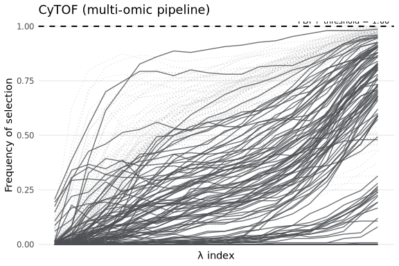

```r
plot_stabl_path(multi_fit$fits$cytof,
                title = "CyTOF (multi-omic pipeline)")
```

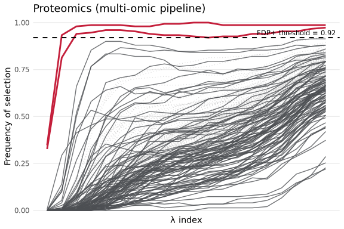

```r
plot_stabl_path(multi_fit$fits$proteomics,
                title = "Proteomics (multi-omic pipeline)")
```

## 5. Export results

[output not shown]

Set `override = TRUE` to overwrite an existing directory; useful in iterative analyses where you re-run with more bootstraps.

```r
out_dir <- file.path(tempdir(), "stablr_ool_cytof")

save_stabl_results(
  object    = multi_fit$fits$cytof,
  path      = out_dir,
  x         = ool_train$x_list$cytof,
  y         = ool_train$y,
  task_type = "regression",
  override  = TRUE
)

list.files(out_dir, recursive = TRUE)
```

```
#> [1] "FDR Graph.pdf"
#> [2] "Max STABL artificial scores.csv"
#> [3] "Max STABL scores.csv"
#> [4] "Selected Features/Selected features.csv"
#> [5] "Stability Path.pdf"
#> [6] "STABL artificial scores.csv"
#> [7] "STABL scores.csv"
```

## Next steps

- Use `stabl_multiomic_cv()` for a fully cross-validated evaluation when no pre-defined validation split is available.
- Pass `groups` to respect subject-level grouping in bootstrap resampling and CV fold construction.
- See `vignette("stablr-intro")` for a walk-through of single-omic usage and alternative learners (adaptive lasso, elastic net).